# GEOG-533 Lab 9

Tianchi Zang

## Question 1

Use R package **UScensus2010county** to complete the following tasks: (20 pt.)

### Question 1(a)

Plot a map of New York counties using the **plot** function.

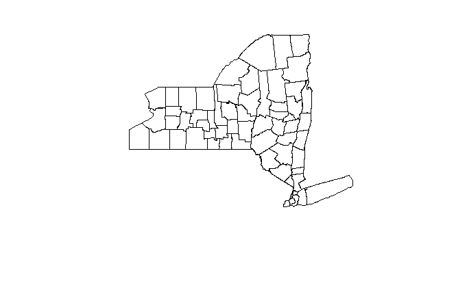

```r
if (!require(UScensus2010)) {install.packages("UScensus2010")}
library(UScensus2010)
if (!require(UScensus2010county)) {install.county("osx")}
if (!require(UScensus2010tract)) {install.tract("osx")}
library(UScensus2010county)
library(UScensus2010tract)
library(rgdal)
data("new_york.county10")
newyork <- new_york.county10
plot(newyork)
```

### Question 1(b)

Plot a map of New York counties using the **qtm** function.

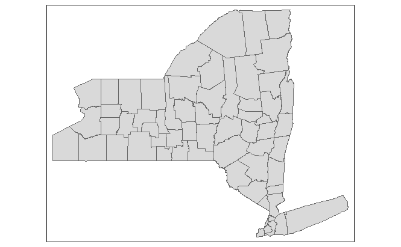

```r
library(tmap)
qtm(newyork)
```

### Question 1(c)

How many counties in New York State?

```r
dfny <- newyork@data
cat("There are", nrow(dfny), "counties in New York State")
```

```
There are 62 counties in New York State
```

### Question 1(d)

What’s the 3-digit **fips** code of Broome County?

```r
broomefips <- as.numeric(dfny$fips[dfny$NAME10 == "Broome"])
cat("The code of Broome County is", sprintf('%03d', broomefips %% 1000))
```

```
The code of Broome County is 007
```

### Question 1(e)

```r
library(e1071)
pop <- dfny$P0010001
cat("The statistics of the population colum \ntotal:", sum(pop), "\nminimum:", min(pop), "\nmaximum:", max(pop), "\nmean:", mean(pop), "\nskewness:", skewness(pop))
```

```
The statistics of the population colum
total: 19378102
minimum: 4836
maximum: 2504700
mean: 312550
skewness: 2.517639
```

### Question 1(f)

Create a histogram and a boxplot of the population.

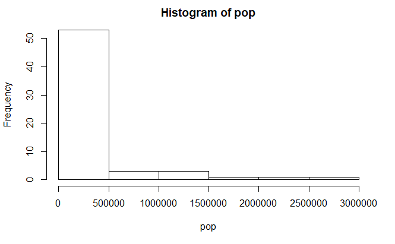

```r
hist(pop)
```

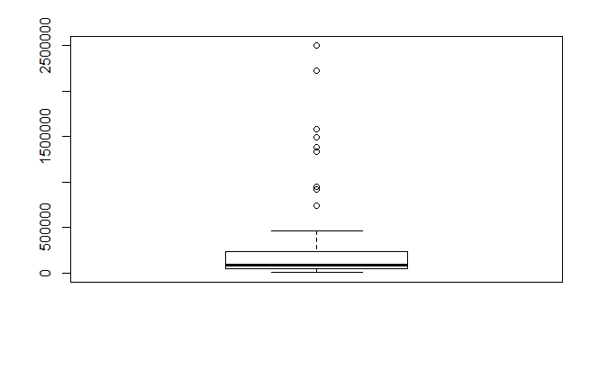

```r
boxplot(pop)
```

## Question 2

Use R package **UScensus2010tract** to complete the following tasks: (20 pt.)

```r
data(new_york.tract10)
```

### Question 2(a)

Plot a map of New York census tracts using the **plot** function.

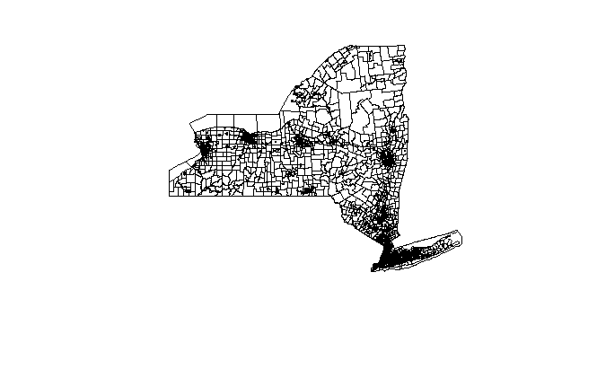

```r
plot(new_york.tract10)
```

### Question 2(b)

Compute the total population based on census tracts.

```r
tract <- new_york.tract10@data
popny <- sum(tract$P0010001)
cat("The total population based on cnesus tracts is", popny)
```

```
The total population based on cnesus tracts is 19378102
```

### Question 2(c)

Select all census tracts in Broome County and plot the map.

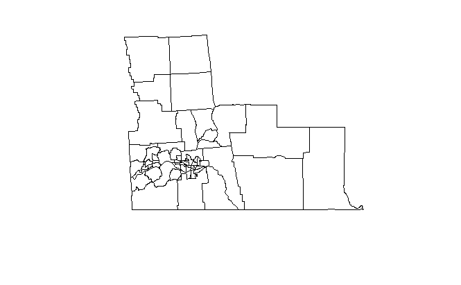

```r
broometracts <- tract$county == sprintf('%03d', broomefips %% 1000)
plot(new_york.tract10[broometracts, ])
```

### Question 2(d)

What’s the total population of Broome County?

```r
popbroome <- tract[broometracts,]$P0010001
cat("The total population of Broome County is", sum(popbroome))
```

```
The total population of Broome County is 200600
```

### Question 2(e)

Create a histogram and a boxplot of population based on census tracts of Broome County.

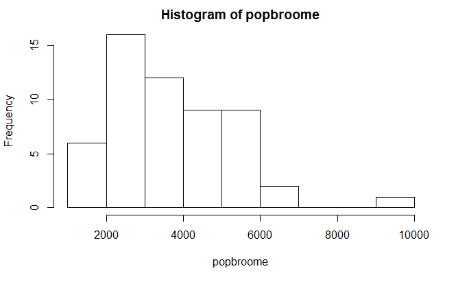

```r
hist(popbroome)
```

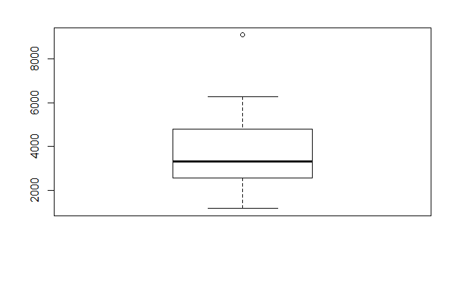

```r
boxplot(popbroome)
```

### Question 2(f)

Select the first five columns of the shapefile of Broome County census tract; add a new population ratio column (= census tract population / county population); save the new shapefile to the hard drive.

```r
tractbroome <- new_york.tract10[broometracts ,c(1:5)]
tractbroome$Pop_ratio <- tractbroome$P0010001 / sum(popbroome)
writeOGR(tractbroome, dsn = "output", 'new_shapefile', driver = "ESRI Shapefile", overwrite_layer = TRUE)
```

```
NAs introduced by coercion
```

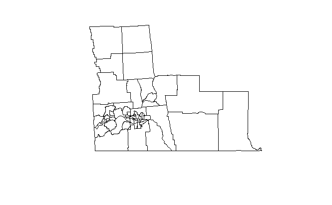

```r
new_shapefile <- readOGR("output", "new_shapefile")
plot(new_shapefile)
```

```r
new_shapefile@data
```

|  | state | county | tract | fips | P0010001 | Pop_ratio |
| --- | --- | --- | --- | --- | --- | --- |
| 0 | 36 | 007 | 012500 | 36007012500 | 6274 | 0.031276171 |
| 1 | 36 | 007 | 011902 | 36007011902 | 2732 | 0.013619143 |
| 2 | 36 | 007 | 000100 | 36007000100 | 3220 | 0.016051844 |
| 3 | 36 | 007 | 000200 | 36007000200 | 3188 | 0.015892323 |
| 4 | 36 | 007 | 000300 | 36007000300 | 2975 | 0.014830508 |
| 5 | 36 | 007 | 000400 | 36007000400 | 2356 | 0.011744766 |
| 6 | 36 | 007 | 000500 | 36007000500 | 1969 | 0.009815553 |
| 7 | 36 | 007 | 000600 | 36007000600 | 2296 | 0.011445663 |
| 8 | 36 | 007 | 000700 | 36007000700 | 3684 | 0.018364905 |
| 9 | 36 | 007 | 000900 | 36007000900 | 1762 | 0.008783649 |

[output cut: 45 more lines]